# Landskapsanalys v2.1: Faktor- och klusterkanslighet

> Denna rapport dokumenterar nasta robusthetspass ovanpa `landskapsanalys_v2_1_geomweight58_res9`: jamforelse mellan `varimax` och `oblimin`, samt mellan `K = 5` och `K = 6`.

## 1. Syfte

Denna rapport svarar pa en mycket konkret metodfraga:

**Vad hander i `v2.1` om vi slutar ta `varimax` och ett enda valt `K` for givet?**

Har testas samma kontextmatris som i landskapsanalys_v2_1.html, men med tva explicita jamforelser:

- `varimax` mot `oblimin`
- `K = 5` mot `K = 6`

Allt annat halls konstant:

- samma `v2.1`-kontextmatris
- samma `5` faktorer
- samma `minres`
- samma `tenBerge`
- samma klusterintervall `K = 5..10`

## 2. Testdesign

Analysen bygger pa 7286 hexagoner och 570 rensade kontextkolumner, direkt lasna fran landskapsanalys_v2_1_geomweight58_res9.

| Komponent | Val |
| --- | --- |
| Kallmodell | landskapsanalys_v2_1_geomweight58_res9 |
| Jämförda rotationer | varimax, oblimin |
| Faktorantal | 5 |
| Jämförda K | 5..10 |
| Fokus-K | 5 och 6 |
| Klusteralgoritm | kmeans (Lloyd, nstart = 50, iter.max = 500) |

## 3. Rotation: Varimax Mot Oblimin

Den viktigaste fragan har ar inte om siffrorna blir lite olika, utan om den landskapliga strukturen faktiskt byter karaktar.

Matched factor congruence ligger mellan 0.97 och 0.99, medan hogsta absoluta faktor-korrelation i oblimin ar 0.163.

### 3.1 Matchad faktorlikhet

| Varimax-faktor | Matchad oblimin-faktor | Kongruens |
| --- | --- | --- |
| MR1 | MR3 | 0.98 |
| MR3 | MR1 | 0.99 |
| MR2 | MR2 | 0.99 |
| MR4 | MR4 | 0.98 |
| MR5 | MR5 | 0.97 |

Det mest slående ar att oblimin i praktiken mest byter ordning pa ett par faktorer. Innehallet ar nara identiskt.

### 3.2 Faktor-korrelationer i oblimin

| Rotation | Faktor fran | Faktor till | Korrelationskoefficient |
| --- | --- | --- | --- |
| oblimin | MR1 | MR3 | 0.163 |
| oblimin | MR1 | MR2 | -0.150 |
| oblimin | MR1 | MR4 | 0.036 |
| oblimin | MR1 | MR5 | -0.081 |
| oblimin | MR3 | MR1 | 0.163 |
| oblimin | MR3 | MR2 | -0.043 |
| oblimin | MR3 | MR4 | 0.120 |
| oblimin | MR3 | MR5 | -0.004 |
| oblimin | MR2 | MR1 | -0.150 |
| oblimin | MR2 | MR3 | -0.043 |
| oblimin | MR2 | MR4 | 0.088 |
| oblimin | MR2 | MR5 | -0.019 |
| oblimin | MR4 | MR1 | 0.036 |
| oblimin | MR4 | MR3 | 0.120 |
| oblimin | MR4 | MR2 | 0.088 |
| oblimin | MR4 | MR5 | 0.044 |
| oblimin | MR5 | MR1 | -0.081 |
| oblimin | MR5 | MR3 | -0.004 |
| oblimin | MR5 | MR2 | -0.019 |
| oblimin | MR5 | MR4 | 0.044 |

Den hogsta absoluta faktor-korrelationen ar 0.163. Det ar inte noll, men det ar heller inte starkt nog for att varimax ska se direkt missvisande ut.

### 3.3 Forklarad varians

| Rotation | Kumulativ forklarad varians |
| --- | --- |
| oblimin | 36.02% |
| varimax | 36.02% |

Den kumulativa forklarade variansen ar i praktiken samma under bada rotationerna. Det betyder att rotationen mest handlar om strukturering och tolkbarhet, inte om hur mycket signal som fangas.

## 4. Kluster: K = 5 Mot K = 6

### 4.1 Silhouette over K

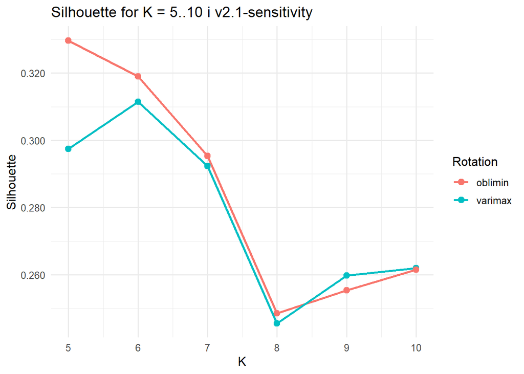

| Rotation | Bast K | Silhouette | Silhouette-basis |
| --- | --- | --- | --- |
| oblimin | 5 | 0.330 | full |
| varimax | 6 | 0.311 | full |

Det finns ingen enda enkel vinnare:

- `oblimin` foredrar `K = 5` med silhouette `0.330`
- `varimax` foredrar `K = 6` med silhouette `0.312`

### 4.2 Fokusjämförelse för K = 5 och K = 6

| Rotation | K | Storsta klustershare | Minsta klustershare | Antal kluster | Silhouette |
| --- | --- | --- | --- | --- | --- |
| oblimin | 5 | 59.2% | 3.0% | 5 | 0.330 |
| oblimin | 6 | 51.2% | 2.8% | 6 | 0.319 |
| varimax | 5 | 56.6% | 4.6% | 5 | 0.297 |
| varimax | 6 | 50.7% | 2.9% | 6 | 0.311 |

Har syns ett tydligt monster:

- `K = 6` ger jamnare klusterbalans an `K = 5`
- `K = 5` ger hogre silhouette under oblimin men ocksa ett storre dominerande kluster
- `varimax K = 6` och `oblimin K = 6` ar nastan samma rumsliga uppdelning

### 4.3 Hur stabil ar klustringen over valen?

| Jamforelse | ARI |
| --- | --- |
| varimax_K5 vs varimax_K6 | 0.705 |
| oblimin_K5 vs oblimin_K6 | 0.724 |
| varimax_K5 vs oblimin_K5 | 0.580 |
| varimax_K6 vs oblimin_K6 | 0.860 |

## 5. Toppladdningar Som Sanity Check

| Rotation | Faktor | Variabel | Laddning |
| --- | --- | --- | --- |
| oblimin | F1 | mean_gc_fastboende_count_k250 | 0.945 |
| oblimin | F1 | std_gc_fastboende_count_k250 | 0.931 |
| oblimin | F1 | std_gc_fastboende_count_k100 | 0.903 |
| oblimin | F1 | mean_gc_fastboende_count_k1000 | 0.900 |
| oblimin | F1 | mean_gc_built_low_selection_share_k1000 | 0.890 |
| oblimin | F2 | mean_gc_jordart_es_flyvesand_share_k1000 | 0.870 |
| oblimin | F2 | mean_gc_jordart_es_flyvesand_share_k250 | 0.855 |
| oblimin | F2 | std_gc_jordart_es_flyvesand_share_k1000 | 0.853 |
| oblimin | F2 | mean_gc_jordart_es_flyvesand_share_k100 | 0.830 |
| oblimin | F2 | std_gc_jordart_es_flyvesand_share_k250 | 0.823 |
| oblimin | F3 | mean_gc_natura_habitat_areas_share_k250 | 0.861 |
| oblimin | F3 | mean_gc_forest_share_k1000 | 0.859 |
| oblimin | F3 | mean_gc_natura_habitat_areas_share_k1000 | 0.853 |
| oblimin | F3 | mean_gc_natura_habitat_areas_share_k100 | 0.851 |
| oblimin | F3 | mean_gc_fredskov_share_k1000 | 0.849 |
| oblimin | F4 | mean_gc_relief_m_k250 | 0.881 |
| oblimin | F4 | mean_gc_relief_m_k1000 | 0.878 |
| oblimin | F4 | mean_gc_relief_m_k100 | 0.855 |
| oblimin | F4 | mean_gc_relief_m_k50 | 0.826 |
| oblimin | F4 | mean_gc_jordart_pkv_prekvartart_lag_share_k1000 | 0.792 |
| oblimin | F5 | mean_gc_jordart_marina_sand_och_grus_ovrigt_share_k1000 | 0.651 |
| oblimin | F5 | mean_gc_jordart_marina_sand_och_grus_ovrigt_share_k250 | 0.634 |
| oblimin | F5 | std_gc_jordart_marina_sand_och_grus_ovrigt_share_k1000 | 0.612 |
| oblimin | F5 | std_gc_jordart_marina_sand_och_grus_ovrigt_share_k250 | 0.608 |
| oblimin | F5 | mean_gc_jordart_marina_sand_och_grus_ovrigt_share_k100 | 0.606 |
| varimax | F1 | mean_gc_jordart_es_flyvesand_share_k1000 | 0.843 |
| varimax | F1 | mean_gc_jordart_es_flyvesand_share_k250 | 0.840 |
| varimax | F1 | std_gc_jordart_es_flyvesand_share_k1000 | 0.835 |
| varimax | F1 | mean_gc_jordart_es_flyvesand_share_k100 | 0.818 |
| varimax | F1 | std_gc_jordart_es_flyvesand_share_k250 | 0.817 |
| varimax | F2 | mean_gc_fastboende_count_k250 | 0.929 |
| varimax | F2 | std_gc_fastboende_count_k250 | 0.922 |
| varimax | F2 | mean_gc_fastboende_count_k1000 | 0.903 |
| varimax | F2 | mean_gc_built_low_selection_share_k1000 | 0.897 |
| varimax | F2 | std_gc_fastboende_count_k100 | 0.887 |
| varimax | F3 | mean_gc_forest_share_k1000 | 0.872 |
| varimax | F3 | mean_gc_forest_share_k250 | 0.867 |
| varimax | F3 | mean_gc_fredskov_share_k1000 | 0.857 |
| varimax | F3 | mean_gc_natura_habitat_areas_share_k250 | 0.849 |
| varimax | F3 | mean_gc_fredskov_share_k250 | 0.842 |
| varimax | F4 | mean_gc_relief_m_k1000 | 0.864 |
| varimax | F4 | mean_gc_relief_m_k250 | 0.852 |
| varimax | F4 | mean_gc_relief_m_k100 | 0.824 |
| varimax | F4 | mean_gc_relief_m_k50 | 0.793 |
| varimax | F4 | mean_gc_jordart_pkv_prekvartart_lag_share_k1000 | 0.787 |
| varimax | F5 | mean_gc_jordart_marina_sand_och_grus_ovrigt_share_k1000 | 0.648 |
| varimax | F5 | mean_gc_jordart_marina_sand_och_grus_ovrigt_share_k250 | 0.631 |
| varimax | F5 | mean_gc_jordart_marina_sand_och_grus_ovrigt_share_k100 | 0.599 |
| varimax | F5 | std_gc_jordart_marina_sand_och_grus_ovrigt_share_k1000 | 0.589 |
| varimax | F5 | std_gc_jordart_marina_sand_och_grus_ovrigt_share_k250 | 0.586 |

Toppladdningarna bekräftar samma sak som kongruensen: oblimin ser inte ut att skapa en helt ny landskapssyn. De stora gradienterna finns kvar, men faktorordningen flyttar sig delvis.

## 6. Arbetsposition

Min arbetsposition efter denna kanslighetsrunda ar:

1. Behall `varimax` som **arbetsdefault** i huvudrapporten tills vidare.
2. Tolka inte detta som att `varimax` nu ar bevisat bast. Det betyder bara att oblimin inte visade stark nog faktorinterdependens for att tvinga ett metodbyte redan nu.
3. Behall bade `K = 5` och `K = 6` som levande kandidater.
4. Anvand `K = 6` som **arbetsval for fortsatt kartgranskning**, eftersom det ar mer balanserat och betydligt stabilare over rotationer.
5. Tolka `oblimin K = 5` som den viktigaste motrosten: enklare kluster ger fortfarande battre separation enligt silhouette, sa vi ska inte lata `K = 6` stelna till sanning for tidigt.

I praktiken betyder det att nasta steg bor vara:

- visuell kartgranskning av `K = 5` mot `K = 6` i `v2.1`
- faktorantalskanslighet ovanpa samma `v2.1`-matris
- leave-one-theme-out pa `v2.1`